# Project Python Foundations: FoodHub Data Analysis

### **Question 12**: Perform a multivariate analysis to explore relationships between the important variables in the dataset. (It is a good idea to explore relations between numerical variables as well as relations between numerical and categorical variables) [10 marks]

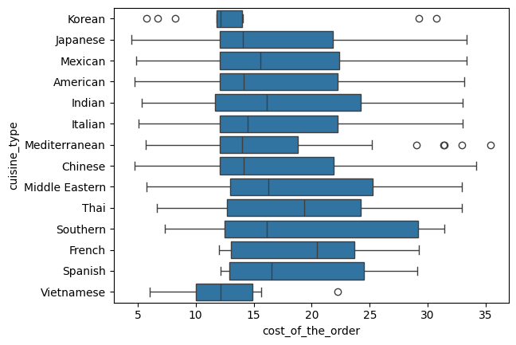

```python
#Plot relationship between cost of order and cuisine type
sns.boxplot(data=df, x='cost_of_the_order', y='cuisine_type')
plt.show()
```

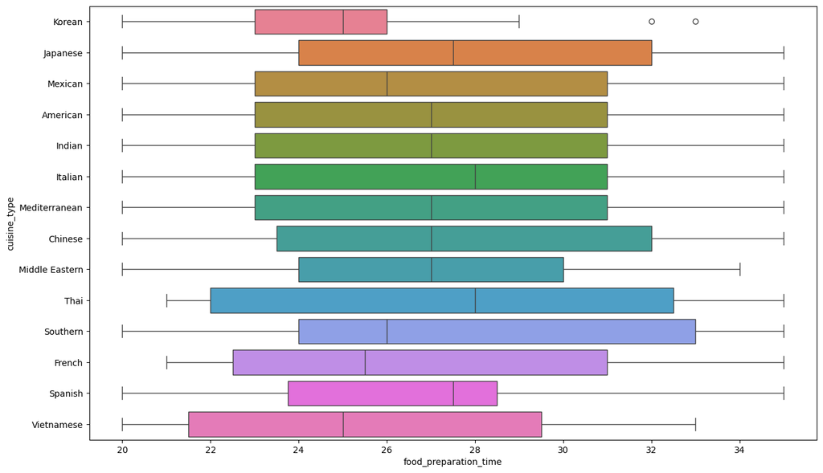

```python
#Relationship between food preparation time and cuisine type
plt.figure(figsize=(15,9))
sns.boxplot(data=df, x='food_preparation_time', y='cuisine_type', hue='cuisine_type')
plt.show()
```

Observation : It takes less time to prepare Korean and Vietnamese Cuisine than others. The minimum and maximum time to prepare seems almost similar among many cuisines except few. The median preparation time for Thai and Italian Cuisine are higher than the rest.

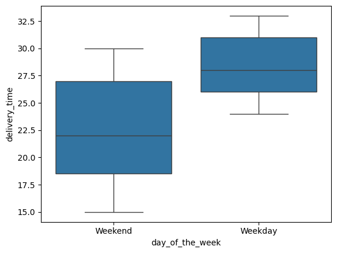

```python
#Relationship between day of the week and delivery time
sns.boxplot(data=df, x='day_of_the_week', y='delivery_time')
plt.show()
```

Observation : It takes more time to deliver during the weekdays than the weekends. Median time to deliver during the weekends is around 22 minutes whereas during he weekdays is 28 minutes.

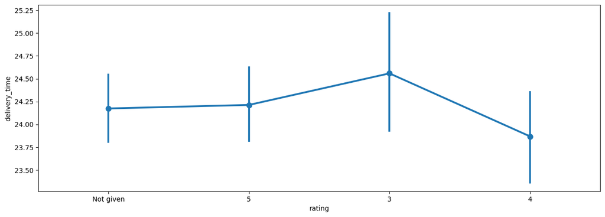

```python
#Relationship between rating and delivery time
plt.figure(figsize=(15,5))
sns.pointplot(data=df, x='rating', y='delivery_time')
plt.show()
```

Observation : There seems to be no relationship between ratings and the delivery time.

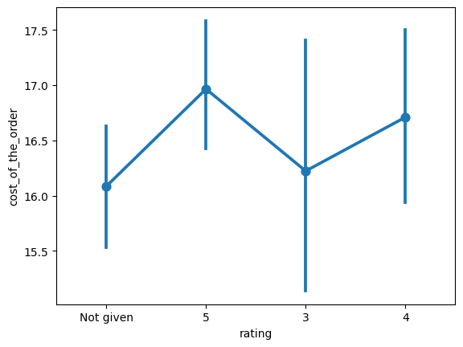

```python
#Relationship between rating and cost of order
sns.pointplot(data=df, x='rating', y='cost_of_the_order')
plt.show()
```

Observation : The ratings are given higher if the cost of the order is higher.

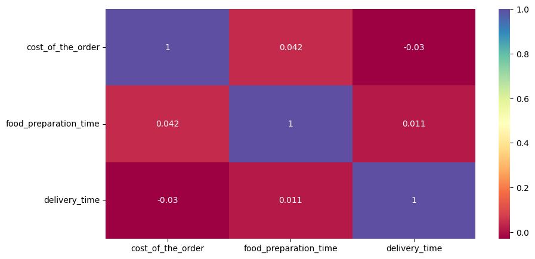

```python
#Plot the heatmap
col_list = ['cost_of_the_order', 'food_preparation_time', 'delivery_time']
plt.figure(figsize=(10,5))
sns.heatmap(df[col_list].corr(), annot=True, cmap="Spectral")
plt.show()
```

Observation : The cost of the order and delivery time have negative correlation. Food preparation time and delivery time has almost null positive correlation. Food preparation and cost of the order have very little correlation.

### **Question 13:** The company wants to provide a promotional offer in the advertisement of the restaurants. The condition to get the offer is that the restaurants must have a rating count of more than 50 and the average rating should be greater than 4. Find the restaurants fulfilling the criteria to get the promotional offer. [3 marks]

```python
#Merge the dataset where both conditions are true i.e rating count more than 50 and mean rating is greater than 4
#exclude if ratings are not given
df_rating_orders = df[df['rating'] != 'Not given'].copy()

# Convert rating column from object to integer
df_rating_orders['rating'] = df_rating_orders['rating'].astype('int')

# restaurants with their rating counts
df_rating_count = df_rating_orders.groupby(['restaurant_name'])['rating'].count().sort_values(ascending = False).reset_index()
df_rating_count.head()
#print(df_rating_count.head())
#print("=================================")

# Restaurant that have more than 50 ratings
restaurant_names = df_rating_count[df_rating_count['rating']>50]['restaurant_name']
print('Restaurant names with rating count > 50:')
print(restaurant_names)
print("=======================================")

# Mean rating for each restaurant
df_mean_4_rating = df_rating_orders.groupby(['restaurant_name'])['rating'].mean().sort_values(ascending = False).reset_index().dropna()
print('The Mean rating for each restaurant:')
print(df_mean_4_rating)
print("===================================")

# get restaurants that have mean rating greater than 4
df_mean_rating_gt_4 = df_mean_4_rating[df_mean_4_rating['rating'] > 4].sort_values(by='rating', ascending=False).reset_index(drop=True)
print('The Restaurants with mean rating > 4 are:')
print(df_mean_rating_gt_4)
print("====================================")

#Merge data sets with inner join where both conditions are met
both_conditions = pd.merge(restaurant_names, df_mean_rating_gt_4, how ='inner', on =['restaurant_name'],sort=['rating'])
print('The Restaurants with rating count > 50 and mean rating > 4 are:')
print(both_conditions)
```

```
Restaurant names with rating count > 50:
0                  Shake Shack
1            The Meatball Shop
2            Blue Ribbon Sushi
3    Blue Ribbon Fried Chicken
Name: restaurant_name, dtype: object
=======================================
The Mean rating for each restaurant:
                   restaurant_name  rating
0                       'wichcraft     5.0
1             Ravagh Persian Grill     5.0
2    Chola Eclectic Indian Cuisine     5.0
3                      Chote Nawab     5.0
4                           Junoon     5.0
..                             ...     ...
151                       Woorijip     3.0
152              Byblos Restaurant     3.0
153                    Pepe Giallo     3.0
154                   Sushi Choshi     3.0
155                Sarabeth's West     3.0

[156 rows x 2 columns]
===================================
The Restaurants with mean rating > 4 are:
            restaurant_name    rating
0                'wichcraft  5.000000
1               Hunan Manor  5.000000
2                     Klong  5.000000
3                  Kanoyama  5.000000
4    Cipriani Le Specialita  5.000000
..                      ...       ...
105            Cafe Mogador  4.153846
106        ilili Restaurant  4.153846
107                    Parm  4.128205
108                Rubirosa  4.125000
109              Bareburger  4.058824

[110 rows x 2 columns]
====================================
The Restaurants with rating count > 50 and mean rating > 4 are:
             restaurant_name    rating
0  Blue Ribbon Fried Chicken  4.328125
1          Blue Ribbon Sushi  4.219178
2                Shake Shack  4.278195
3          The Meatball Shop  4.511905
```

#### Observations: The Restaurants with rating count greater than 50 and mean ratings greater than 4 in highest order are The Meatball Shop, Blue Ribbon Fried Chicken, SHake Shack and Blue Ribbon Sushi. These Restaurants fulfills the criteria set for Promotional Offers.

### **Question 14:** The company charges the restaurant 25% on the orders having cost greater than 20 dollars and 15% on the orders having cost greater than 5 dollars. Find the net revenue generated by the company across all orders. [3 marks]

```python
# Write the code here
# Define a function to calculate revenue based on cost
def calculate_revenue(cost):
    if cost > 20:
        return cost * 0.25
    elif cost > 5:
        return cost * 0.15
    else:
        return 0

# Apply the function to the 'cost_of_the_order' column
df['revenue'] = df['cost_of_the_order'].apply(calculate_revenue)

# Sum the 'revenue' column
revenue_generated = df['revenue'].sum()

print('The revenue generated is around', round(revenue_generated, 2), 'dollars')
```

```
The revenue generated is around 6166.3 dollars
```

#### Observations: The revenue generated is around 6166.3 dollars

### **Question 15:** The company wants to analyze the total time required to deliver the food. What percentage of orders take more than 60 minutes to get delivered from the time the order is placed? (The food has to be prepared and then delivered.) [2 marks]

```python
# Write the code here
# Calculate total delivery time
df['total_delivery_time'] = df['food_preparation_time'] + df['delivery_time']

# Calculate the number and percentage of orders with total delivery time > 60 minutes
total_orders = df.shape[0]
orders_over_60 = df['total_delivery_time'] > 60
num_orders_over_60 = orders_over_60.sum()
percentage_over_60 = (num_orders_over_60 / total_orders) * 100

print('The number of orders that take more than 60 minutes to deliver:', num_orders_over_60)
print("Percentage of orders that take more than 60 minutes to deliver:", round(percentage_over_60, 2), '%')
```

```
The number of orders that take more than 60 minutes to deliver: 200
Percentage of orders that take more than 60 minutes to deliver: 10.54 %
```

### **Question 16:** The company wants to analyze the delivery time of the orders on weekdays and weekends. How does the mean delivery time vary during weekdays and weekends? [2 marks]

```python
# Write the code here
# Calculate mean delivery time for weekdays and weekends
mean_delivery_time = df.groupby('day_of_the_week')['delivery_time'].mean().round()

# Extract means for weekdays and weekends
mean_weekday = mean_delivery_time.get('Weekday', 0)
mean_weekend = mean_delivery_time.get('Weekend', 0)

# Calculate the difference
mean_diff = mean_weekday - mean_weekend

print('The mean delivery time on weekdays is around', mean_weekday, 'minutes')
print('The mean delivery time on weekends is around', mean_weekend, 'minutes')
print('The difference between mean delivery times between weekdays and weekend is', mean_diff, 'minutes')
```

```
The mean delivery time on weekdays is around 28.0 minutes
The mean delivery time on weekends is around 22.0 minutes
The difference between mean delivery times between weekdays and weekend is 6.0 minutes
```

### Conclusion and Recommendations

### **Question 17:** What are your conclusions from the analysis? What recommendations would you like to share to help improve the business? (You can use cuisine type and feedback ratings to drive your business recommendations.) [6 marks]

### Conclusions:

1. Cuisine Types: The following cuisine types have received the highest ratings of 4 and 5 and are in high demand:

   American Japanese Italian Chinese Indian Mexican

These cuisine types also account for a significant number of orders.

1. Top Rated Restaurants: The following restaurants are highly rated and have the highest number of orders: The Meatball Shop Blue Ribbon Fried Chicken Shake Shack Blue Ribbon Sushi

### Recommendations:

1. Personnel Allocation:

Given that the number of orders is higher on weekends compared to weekdays, it is recommended to increase the number of delivery personnel available during weekends. For the top-rated restaurants (The Meatball Shop, Blue Ribbon Fried Chicken, Shake Shack, Blue Ribbon Sushi), we need to ensure that additional delivery personnel are allocated to handle the high volume of orders.

1. Cuisine-Specific Staffing:

Allocate more delivery personnel to handle orders for the following high-demand cuisine types: American Japanese Italian Chinese Indian Mexican

1. Delivery Time Optimization: